# **BUDT758X Course Project**

# **Global Terrorist Data - Descriptive Analysis**

*Submitted by: Group 10*

**Aashika Rudraraju**

**Vishnu Maddi**

**Mourya Bandaluppi**

# **Database information:**

The Global Terrorism Database (GTD) is an open-source database including information on terrorist events around the world from 1970 through 2017 (with additional annual updates planned). Unlike many other event databases, the GTD includes systematic data on domestic as well as transnational and international terrorist incidents that have occurred date and location of the incident, the weapons used and nature of the target, the number of casualties, and--when identifiable--the group or individual responsible. The National Consortium for the Study of Terrorism and Responses to Terrorism (START) makes the GTD available via this online interface in an effort to increase understanding of terrorist violence so that it can be more readily studied and defeated.

# **Characteristics of the GTD:**

• Contains information on over 180,000 terrorist attacks.

• Currently the most comprehensive unclassified database on terrorist attacks in the world.

• Includes information on more than 88,000 bombings, 19,000 assassinations, and 11,000 kidnappings since 1970.

• Includes information on at least 45 variables for each case, with more recent incidents including information on more than 120 variables.

Note: In the GTD data, the data for the year 1993 is missing and we have decided to ignore this as it won’t be having much impact on the overall data analysis.

[1] The GTD data can be downloaded from https://www.start.umd.edu/gtd in .xlsx form and it has been converted to .csv after downloading.

[2] Details about the variables and their meanings can be found and downloaded from the data dictionary (GTD Code Book) which is available at http://start.umd.edu/gtd/downloads/Codebook.pdf

# **Objectives**

**1. Cleaning and Preparing the data for Analysis**

• Identify the significant variable groups contributing to our analysis – events(attacks) details like location(country, region, city, latitude, longitude), when it happened(year, month), criteria, attack type, target type, terrorist group, weapon type used for the attack, number of kills, injured, property loss value, hostage taken or not.

• Renaming the columns for analysis convenience.

• Identify the string type columns with white spaces and deleting them from analysis.

• Find the NaN cells in the dataset and replacing with 0’s or 1’s or particular text corresponding to the column type.

• Identify the observations which have data with special characters like series of “ . ”, “ – “ etc and replacing them with “Unknown”.

• Resetting the index.

**2. Study the following trends**

• Number of attacks over the years

• Number of people killed over the years due to terrorist attacks

• Regions affected by terrorists attacks over the years

• Number of failed attacks (zero number of people killed is the criteria)

• Property loss over the years (not accounting inflation)

• Are there any changes in type of attack, target type over the years

• How lethal are the attacks over the years?

**3. Identify the top deadliest terrorist groups (more killings and attacks) in each decade**.

• Spread of each group from their inception

• How long does an average terrorist group be active?

**4. Identify the top 10 countries experiencing terrorist attacks after 2000 and analyze the following parameters for each country**

• Which terrorist groups are dominant in each of the country?

• Property value loss

• Number of people killed

• Attack type, Target types, Weapon type

• Find the factors or real life events contributing to these attacks.

**5. Study and research in detail the reasons for increase in attacks in the year 2014 globally.**

# **Variables of Significance:**

The dataset has 181691 records with 135 columns. We have chosen the variables of significance by choosing a subset of all the variables for analyzing the GTD Data. They are iyear, imonth, extended, country_txt, region_txt, provstate, city, latitude, longitude, crit1, crit2, multiple, success, suicide, attacktype1_txt, targtype1_txt, gname, claimed, weaptype1_txt, nkill, nkillus, nkillter, nwound, nwoundus, nwoundte, property, propextent_txt

# **Data Cleansing:**

**(1) We have renamed some of the variables of significance from the GTD format to a readable english format such as iyear, imonth, country_txt, region_txt etc**

```python
col = [1,2,3, 5, 8, 10, 11, 12, 13, 14,19,20, 25, 26, 27, 29, 35, 58, 71, 82, 98, 99, 100, 101, 102, 103, 104, 106]
renamecol = {
    'latitude': 'Latitude',
    'longitude': 'Longitude',
    'iyear': 'Year',
    'imonth': 'Month_of_attack',
    'country_txt': 'Country',
    'region_txt': 'Region',
    'provstate': 'State',
    'attacktype1_txt': 'Attack_type',
    'targtype1_txt': 'Target_type',
    'weaptype1_txt': 'Weapon_type',
    'nperps': 'Number_of_terrorists',
    'nkill': 'Number_of_killed',
    'nkillter': 'Number_of_killed_terrorists',
    'nwound': 'Number_of_people_wounded',
    'nwoundte': 'Number_of_wounded_terrorists',
    'propextent_txt': 'propertyextent'
}
```

**(2) Reading the csv file and renaming the specific column names. The name of the csv file is globalterrorism.csv. It initially has the ISO-8859-1 encoding. We have used df.columns to check if all the variables of significance are present in the dataframe.**

```python
import pandas as pd
import numpy as np

df = pd.read_csv('globalterrorism.csv', encoding='ISO-8859-1',usecols=col)
df.rename(columns=renamecol, inplace=True)
df = df.apply(lambda x: x.encode('utf-8').strip() if isinstance(x, str) else x)
df.head(5)
print(df.columns)
#print(df.shape)
```

```
Index(['Year', 'Month_of_attack', 'iday', 'extended', 'Country', 'Region',
       'State', 'city', 'Latitude', 'Longitude', 'crit1', 'crit2', 'multiple',
       'success', 'suicide', 'Attack_type', 'Target_type', 'gname', 'claimed',
       'Weapon_type', 'Number_of_killed', 'nkillus',
       'Number_of_killed_terrorists', 'Number_of_people_wounded', 'nwoundus',
       'Number_of_wounded_terrorists', 'property', 'propertyextent'],
      dtype='object')
```

**(3) In the dataset, some of the records have the value of "0" for month of attack. So, we have removed the rows which have the month as "0".**

```python
# Remove zero values in date
#df = df.drop(df[df.Year == 0].index)
df=df.drop(df[df.Month_of_attack==0].index)
df.reset_index(drop=True,inplace=True)
df.index+=1
df.head(5)
```

|  | Year | Month_of_attack | iday | extended | Country | Region | State | city | Latitude | Longitude | ... | claimed | Weapon_type | Number_of_killed | nkillus | Number_of_killed_terrorists | Number_of_people_wounded | nwoundus | Number_of_wounded_terrorists | property | propertyextent |
| --- | --- | --- | --- | --- | --- | --- | --- | --- | --- | --- | --- | --- | --- | --- | --- | --- | --- | --- | --- | --- | --- |
| 1 | 1970 | 7 | 2 | 0 | Dominican Republic | Central America & Caribbean | NaN | Santo Domingo | 18.456792 | -69.951164 | ... | NaN | Unknown | 1.0 | NaN | NaN | 0.0 | NaN | NaN | 0 | NaN |
| 2 | 1970 | 1 | 0 | 0 | Philippines | Southeast Asia | Tarlac | Unknown | 15.478598 | 120.599741 | ... | NaN | Unknown | 1.0 | NaN | NaN | 0.0 | NaN | NaN | 0 | NaN |
| 3 | 1970 | 1 | 0 | 0 | Greece | Western Europe | Attica | Athens | 37.997490 | 23.762728 | ... | NaN | Explosives | NaN | NaN | NaN | NaN | NaN | NaN | 1 | NaN |
| 4 | 1970 | 1 | 0 | 0 | Japan | East Asia | Fukouka | Fukouka | 33.580412 | 130.396361 | ... | NaN | Incendiary | NaN | NaN | NaN | NaN | NaN | NaN | 1 | NaN |
| 5 | 1970 | 1 | 1 | 0 | United States | North America | Illinois | Cairo | 37.005105 | -89.176269 | ... | 0.0 | Firearms | 0.0 | 0.0 | 0.0 | 0.0 | 0.0 | 0.0 | 1 | Minor (likely < $1 million) |

5 rows × 28 columns

**(4) We have removed the rows for which the value of Latitude or Longitude are blank. Also, some of the group names are in the form of dates as seen in the code. We have removed the ganame with such abnormal names.**

```python
#Removing gname which are incorrectly mentioned in the dataset
df = df[pd.notnull(df.Latitude)]
df = df[pd.notnull(df.Longitude)]
df = df[~df['gname'].isin(['22-Jan','Oct-80','9-Feb','22-May-48','1-May','May-36','15-May','May-98'])]
k_grp=df.loc[df['gname'] == '22-Jan']
display(k_grp)
print(df.shape)
```

|  | Year | Month_of_attack | iday | extended | Country | Region | State | city | Latitude | Longitude | ... | claimed | Weapon_type | Number_of_killed | nkillus | Number_of_killed_terrorists | Number_of_people_wounded | nwoundus | Number_of_wounded_terrorists | property | propertyextent |
| --- | --- | --- | --- | --- | --- | --- | --- | --- | --- | --- | --- | --- | --- | --- | --- | --- | --- | --- | --- | --- | --- |

0 rows × 28 columns

```
(177118, 28)
```

**(5) In the numerical columns like crit1, claimed etc, we found that there are some NaNs. We don't want any NaNs as they automatically convert the column to dtype=float. So we tried to clean them by using fillna()**

```python
# Deal with unknowns in numeric columns
numerical_unknowns = ['Latitude', 'Longitude','Year']
float_cols = [c for c in df.select_dtypes(include=[float]).columns.tolist() if c not in numerical_unknowns]
# We don't want any NaNs as they automatically convert the column to dtype=float
# Convert the unknowns into negative numbers, say -9
df[float_cols] = df[float_cols].fillna(0).astype(int)
df[float_cols] = df[float_cols].mask(df[float_cols] < 0, 0)
df.head(5)
#df[float_cols]
```

|  | Year | Month_of_attack | iday | extended | Country | Region | State | city | Latitude | Longitude | ... | claimed | Weapon_type | Number_of_killed | nkillus | Number_of_killed_terrorists | Number_of_people_wounded | nwoundus | Number_of_wounded_terrorists | property | propertyextent |
| --- | --- | --- | --- | --- | --- | --- | --- | --- | --- | --- | --- | --- | --- | --- | --- | --- | --- | --- | --- | --- | --- |
| 1 | 1970 | 7 | 2 | 0 | Dominican Republic | Central America & Caribbean | NaN | Santo Domingo | 18.456792 | -69.951164 | ... | 0 | Unknown | 1 | 0 | 0 | 0 | 0 | 0 | 0 | NaN |
| 2 | 1970 | 1 | 0 | 0 | Philippines | Southeast Asia | Tarlac | Unknown | 15.478598 | 120.599741 | ... | 0 | Unknown | 1 | 0 | 0 | 0 | 0 | 0 | 0 | NaN |
| 3 | 1970 | 1 | 0 | 0 | Greece | Western Europe | Attica | Athens | 37.997490 | 23.762728 | ... | 0 | Explosives | 0 | 0 | 0 | 0 | 0 | 0 | 1 | NaN |
| 4 | 1970 | 1 | 0 | 0 | Japan | East Asia | Fukouka | Fukouka | 33.580412 | 130.396361 | ... | 0 | Incendiary | 0 | 0 | 0 | 0 | 0 | 0 | 1 | NaN |
| 5 | 1970 | 1 | 1 | 0 | United States | North America | Illinois | Cairo | 37.005105 | -89.176269 | ... | 0 | Firearms | 0 | 0 | 0 | 0 | 0 | 0 | 1 | Minor (likely < $1 million) |

5 rows × 28 columns

**(6) We have cleaned the columns having non-numeric unknown values and replaced them to the word "Unknown"**

```python
# Deal with unknowns in string columns
str_cols = df.select_dtypes(exclude=[float]).columns.tolist()
df[str_cols] = df[str_cols].fillna('Unknown')
# Many fields are dots which mean unknown value
df[str_cols] = df[str_cols].replace(r'^\.*$', 'Unknown', regex=True)
df.head(5)
#print(df[str_cols])
```

|  | Year | Month_of_attack | iday | extended | Country | Region | State | city | Latitude | Longitude | ... | claimed | Weapon_type | Number_of_killed | nkillus | Number_of_killed_terrorists | Number_of_people_wounded | nwoundus | Number_of_wounded_terrorists | property | propertyextent |
| --- | --- | --- | --- | --- | --- | --- | --- | --- | --- | --- | --- | --- | --- | --- | --- | --- | --- | --- | --- | --- | --- |
| 1 | 1970 | 7 | 2 | 0 | Dominican Republic | Central America & Caribbean | Unknown | Santo Domingo | 18.456792 | -69.951164 | ... | 0 | Unknown | 1 | 0 | 0 | 0 | 0 | 0 | 0 | Unknown |
| 2 | 1970 | 1 | 0 | 0 | Philippines | Southeast Asia | Tarlac | Unknown | 15.478598 | 120.599741 | ... | 0 | Unknown | 1 | 0 | 0 | 0 | 0 | 0 | 0 | Unknown |
| 3 | 1970 | 1 | 0 | 0 | Greece | Western Europe | Attica | Athens | 37.997490 | 23.762728 | ... | 0 | Explosives | 0 | 0 | 0 | 0 | 0 | 0 | 1 | Unknown |
| 4 | 1970 | 1 | 0 | 0 | Japan | East Asia | Fukouka | Fukouka | 33.580412 | 130.396361 | ... | 0 | Incendiary | 0 | 0 | 0 | 0 | 0 | 0 | 1 | Unknown |
| 5 | 1970 | 1 | 1 | 0 | United States | North America | Illinois | Cairo | 37.005105 | -89.176269 | ... | 0 | Firearms | 0 | 0 | 0 | 0 | 0 | 0 | 1 | Minor (likely < $1 million) |

5 rows × 28 columns

# **Analysis and Visualizations:**

We have tried to explore the cleaned dataset and have come-up with the following analysis and visualizations.

**1) Number of Civilians killed every year**

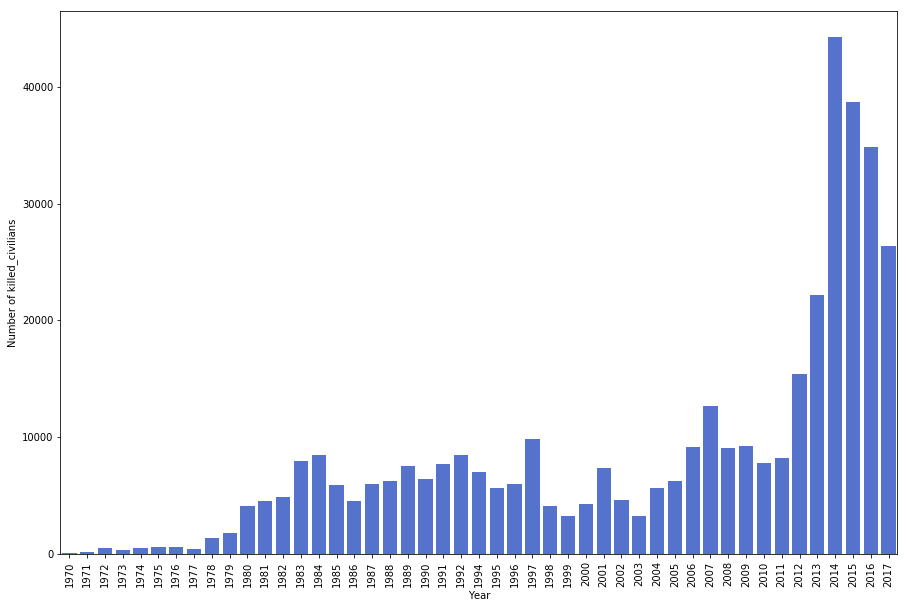

```python
import seaborn as sns
from matplotlib import pyplot as plt
df['Number_of_killed'].fillna(0)
no_of_killed_civilians = df.groupby('Year')['Number_of_killed'].sum()
plt.subplots(figsize=(15,10))
pt1 = sns.barplot(no_of_killed_civilians.index,no_of_killed_civilians,color='royalblue')
pt1.set_xlabel("Year")
pt1.set_ylabel("Number of killed_civilians")
pt1.set_xticklabels(no_of_killed_civilians.index,rotation=90)
plt.show()
```

From the above visualization we can see that over the years, in the year 2014, 100 countries experienced the attacks and 44,490 people killed. This shows us that the worst year for terrorism over the past couple of decades is 2014.

Similar kind of stories indicating that 2014 was the year where terrorism was at its peak point can be interpreted from the visualizations 2,3 and 4.

**2) Number of people killed in each region over the years:**

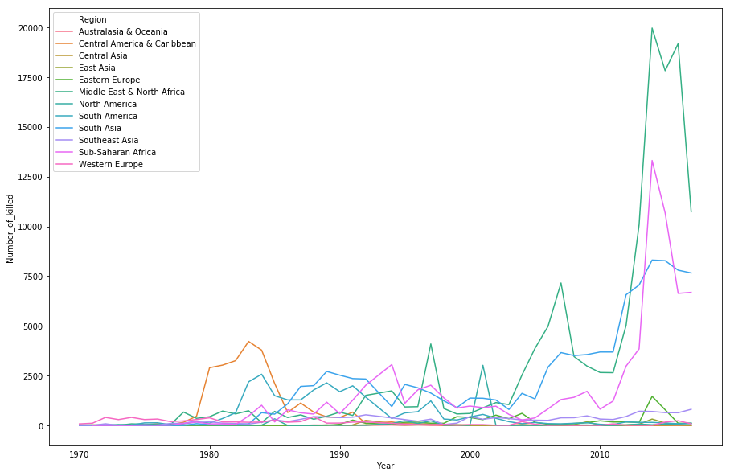

```python
#Number of people killed in each region based on the years
plt.subplots(figsize=(15,10))
df4 = df.groupby(['Region','Year'])['Number_of_killed'].sum()
d = pd.DataFrame(df4)
d.reset_index(level=0,inplace=True)
d.columns = ['Region','Number_of_killed']
d.reset_index(level=0,inplace=True)
#print(d)
color_set = ["#e82727","#ff8649","#ffc549","#fced20","#8fe222","#22e28e","#22e2db","#1f85c4","#361599","#d11fce","#00ff99","#fa97fc"]
t = sns.lineplot(x='Year',y='Number_of_killed',hue='Region',data=d)
t.set_xlabel("Year")
plt.show()
```

**3) Number of attacks of all types based on the year**

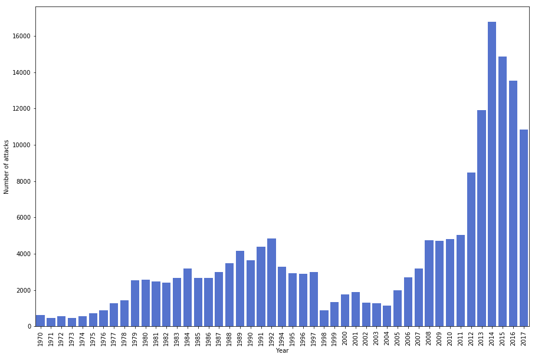

```python
import seaborn as sns
from matplotlib import pyplot as plt
#df['Number_of_killed'].fillna(0)
no_of_attacks = df.groupby('Year')['Attack_type'].count()
plt.subplots(figsize=(15,10))
pt_attacks = sns.barplot(no_of_attacks.index,no_of_attacks,color='royalblue')
pt_attacks.set_xlabel("Year")
pt_attacks.set_ylabel("Number of attacks")
pt_attacks.set_xticklabels(no_of_attacks.index,rotation=90)
plt.show()
```

**4) Number of attacks in regions on the basis of Political and socio-economic factors**

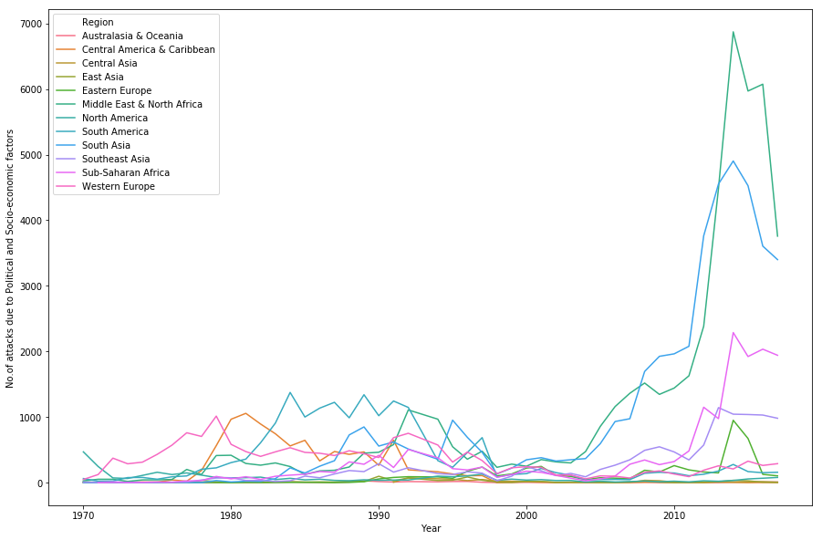

```python
# Graph based on the number of attacks in regions on the basis of criteria 1 (Political and socio-economic factors)

import pandas as pd
plt.subplots(figsize=(15,10))
crit1_true = df['crit1']==1
#print(crit1_true.head())
df7 = df[crit1_true]
#print(df7.head())
df8 = pd.DataFrame(df7.groupby(['Region','Year'])['Number_of_killed'].count())
#print(df8)
df8.reset_index(level=0,inplace=True)
#print(df8.head(3))
df8.columns = ['Region','No.of attacks due to Political and Socio-economic factors']
df8.reset_index(level=0,inplace=True)
#display(df8.head(100))
#print(d)
#color_set = ["#e82727","#ff8649","#ffc549","#fced20","#8fe222","#22e28e","#22e2db","#1f85c4","#361599","#d11fce","#00ff99","#fa97fc"]
t = sns.lineplot(x='Year',y='No.of attacks due to Political and Socio-economic factors',hue='Region',data=df8)
t.set_xlabel("Year")
plt.show()
```

**5) Number of attacks in regions for intimidating people**

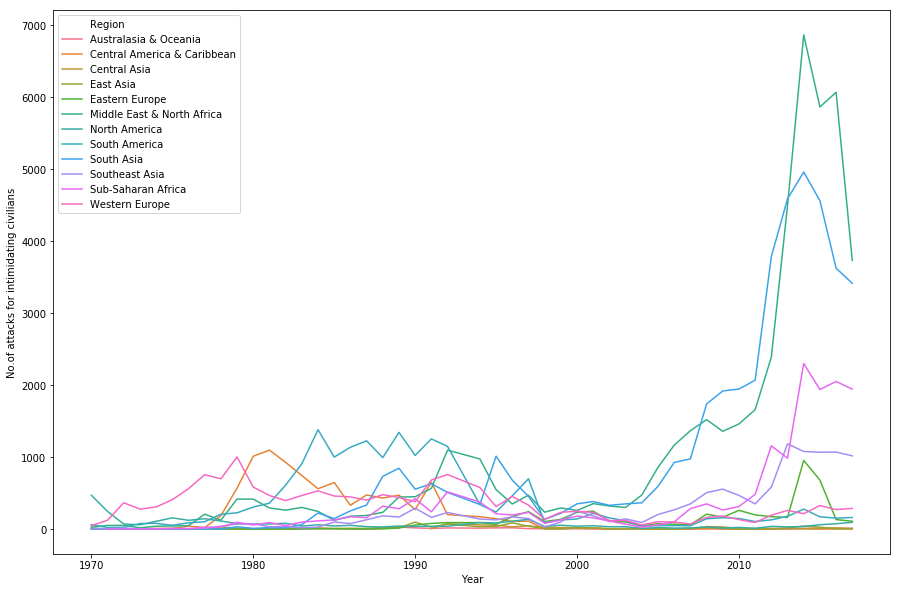

```python
#Number of attacks based on the criteria 2 (For intimidating people)
plt.subplots(figsize=(15,10))
crit2_true = df['crit2']==1
df9 = df[crit2_true]
df10 = pd.DataFrame(df9.groupby(['Region','Year'])['Number_of_killed'].count())
df10.reset_index(level=0,inplace=True)
df10.columns = ['Region','No.of attacks for intimidating civilians']
df10.reset_index(level=0,inplace=True)
t1 = sns.lineplot(x='Year',y='No.of attacks for intimidating civilians',hue='Region',data=df10)
t1.set_xlabel("Year")
plt.show()
```

From the above Visualizations 4 and 5, we can deduce that the number of attacks based on category1 and category2 are highly correlated with each other as the attacks which are aimed for intimidating people also has an affect on socio-economic factors and vice versa.

**6) Identifying the dangerous terrorist groups based on the number of attacks and number of people killed**

```python
#Identifying the dangerous terrorist groups based on the number of attacks and number of people killed
#plt.subplots(figsize=(15,10))
df = df[~df['gname'].isin(['Unknown'])]
df13 = pd.DataFrame(df.groupby(['gname'])['Number_of_killed'].agg(['sum','count']))
df13.reset_index(level=0,inplace=True)

df13 = df13.rename(columns={'sum':'Number of people killed'})
df13 = df13.rename(columns={'count':'Number of attacks'})
df13 = df13.sort_values(by=['Number of people killed','Number of attacks'], ascending = False)
df13 = df13.astype({"Number of people killed": int})
df13.reset_index(level=0,inplace=True,drop=True)
display(df13.head(10))
```

|  | gname | Number of people killed | Number of attacks |
| --- | --- | --- | --- |
| 0 | Islamic State of Iraq and the Levant (ISIL) | 38775 | 5584 |
| 1 | Taliban | 29382 | 7457 |
| 2 | Boko Haram | 20290 | 2408 |
| 3 | Liberation Tigers of Tamil Eelam (LTTE) | 10733 | 1554 |
| 4 | Shining Path (SL) | 10174 | 4306 |
| 5 | Al-Shabaab | 9320 | 3274 |
| 6 | Farabundo Marti National Liberation Front (FMLN) | 7584 | 2991 |
| 7 | Tehrik-i-Taliban Pakistan (TTP) | 6019 | 1349 |
| 8 | Revolutionary Armed Forces of Colombia (FARC) | 5036 | 2332 |
| 9 | Nicaraguan Democratic Force (FDN) | 4642 | 677 |

The above dataframe shows us the top terrorist groups based on the number of attacks and the number of people killed.

The top 3 terrorist groups being:

1) Islamic State of Iraq and the Levant (ISIL)

2) Taliban

3) Boko Haram

```python
# Number of attacks done by a particular terrorist group over a range of years
def attacks_per_month(df9,gname,year):
    data = df9[(df9['gname']==gname) & (df9['Year']==year)]
    attacks_month = data.groupby(['Month_of_attack'])['Number_of_killed'].sum()
    plot2 = sns.barplot(attacks_month.index ,attacks_month,color='royalblue')
    plot2.set_xlabel('Months')
    plot2.set_ylabel('Number of Attacks')
    plot2.set_title(gname + " in "+str(year))
    plt.show()
```

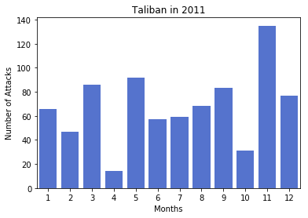

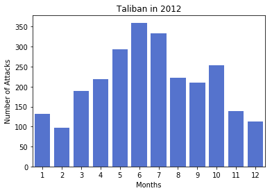

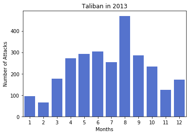

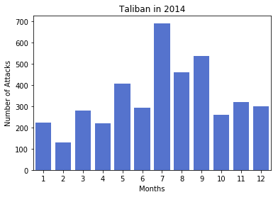

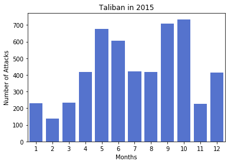

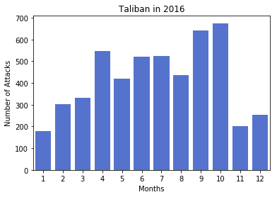

```python
for i in range(2011,2017):
    attacks_per_month(df,"Taliban",i)
```

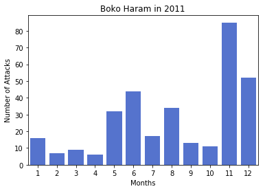

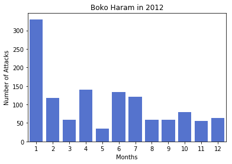

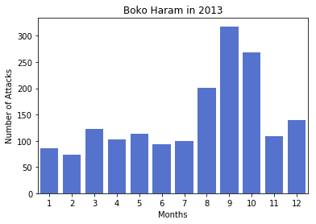

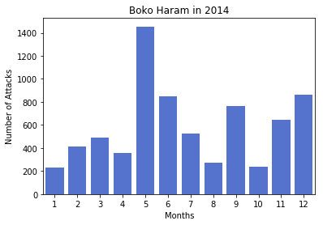

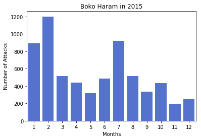

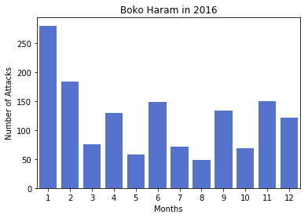

```python
for i in range(2011,2017):
    attacks_per_month(df,"Boko Haram",i)
```

**9) Number of people killed in each region based on the years**

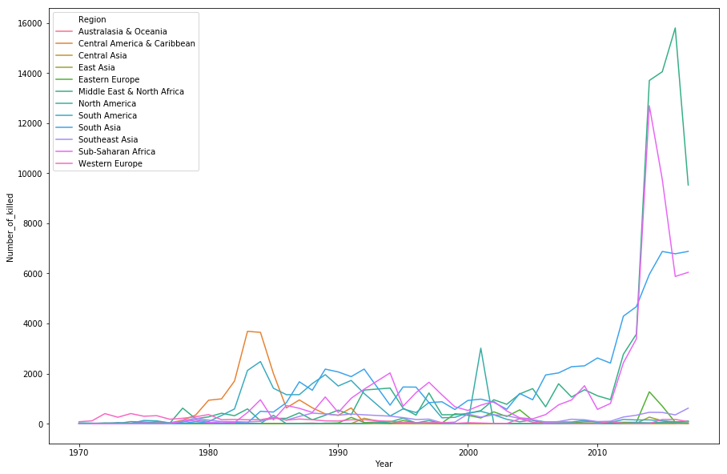

```python
#Number of people killed in each region based on the years
plt.subplots(figsize=(15,10))
df4 = df.groupby(['Region','Year'])['Number_of_killed'].sum()
d = pd.DataFrame(df4)
d.reset_index(level=0,inplace=True)
d.columns = ['Region','Number_of_killed']
d.reset_index(level=0,inplace=True)
#print(d)
color_set = ["#e82727","#ff8649","#ffc549","#fced20","#8fe222","#22e28e","#22e2db","#1f85c4","#361599","#d11fce","#00ff99","#fa97fc"]
t = sns.lineplot(x='Year',y='Number_of_killed',hue='Region',data=d)
t.set_xlabel("Year")
plt.show()
```

**10) Number of people killed based on year in Middle East and North Africa**

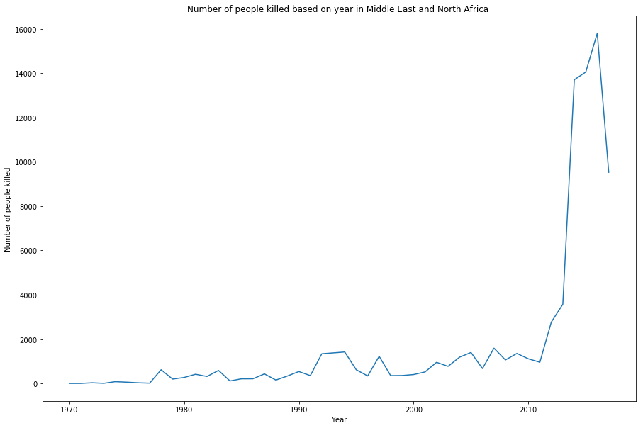

```python
plt.subplots(figsize=(15,10))
data = df[df['Region']=='Middle East & North Africa']
region_groups = data.groupby(["Year"])
df2=pd.DataFrame(region_groups['Number_of_killed'].sum())
#df1 = pd.DataFrame(data.groupby(['Year'])['Number_of_killed'].sum())
df2.reset_index(inplace=True)
#print(df2)
l = sns.lineplot(x="Year",y="Number_of_killed",data=df2)
l.set_title("Number of people killed based on year in Middle East and North Africa ")
l.set_xlabel("Year")
l.set_ylabel("Number of people killed")
plt.show(l)
```

• Based on the above Visualizations, we analyzed and suspected that the spike in 2014 could be because of any of the top 3 terrorist groups in the "Middle East and Nort African" region because of both Political and socio-economic factors and to intimidate people.

• The same has been published in the BBC article "Terror attacks increased by a third in 2014, US says" which says that; "The US State Department says the number of terrorist attacks around the world rose by a third in 2014 compared with the previous year. The sharp increase was largely due to groups like Islamic State in Iraq and Boko Haram in Nigeria." which are in the top 3 dangerous terrorist groups.

Source: https://www.bbc.com/news/world-us-canada-33206784

**11) Visualization based on attack type**

```
Index(['Year', 'Month_of_attack', 'iday', 'extended', 'Country', 'Region',
       'State', 'city', 'Latitude', 'Longitude', 'crit1', 'crit2', 'multiple',
       'success', 'suicide', 'Attack_type', 'Target_type', 'gname', 'claimed',
       'Weapon_type', 'Number_of_killed', 'nkillus',
       'Number_of_killed_terrorists', 'Number_of_people_wounded', 'nwoundus',
       'Number_of_wounded_terrorists', 'property', 'propertyextent'],
      dtype='object')
```

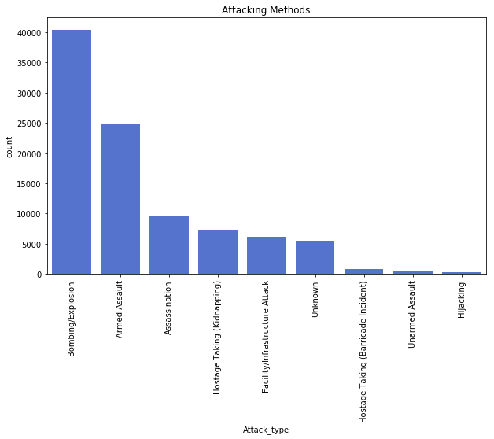

```python
print(df.columns)
plt.subplots(figsize=(10,6))
sns.countplot('Attack_type',data=df,order=df['Attack_type'].value_counts().index,color='royalblue')
plt.xticks(rotation=90)
plt.title('Attacking Methods')
plt.show()
```

**12) Number of attacks on the basis of weapons**

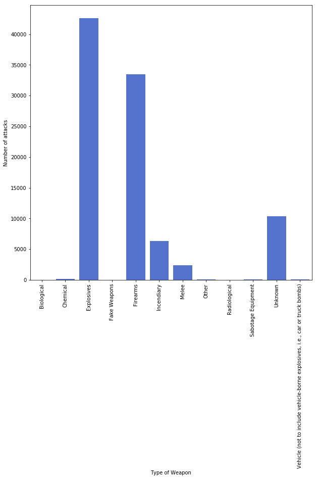

```python
# Number of attacks on the basis of weapons

import seaborn as sns
from matplotlib import pyplot as plt
df['Weapon_type'].fillna(0)
weapons = df.groupby(['Weapon_type'])['Year'].count()
plt.subplots(figsize=(10,10))
pt1 = sns.barplot(weapons.index,weapons,color="royalblue")
pt1.set_xlabel("Type of Weapon")
pt1.set_ylabel("Number of attacks")

pt1.set_xticklabels(weapons.index,rotation=90)
plt.show()
```

**13) Top 10 countries which are mostly attacked**

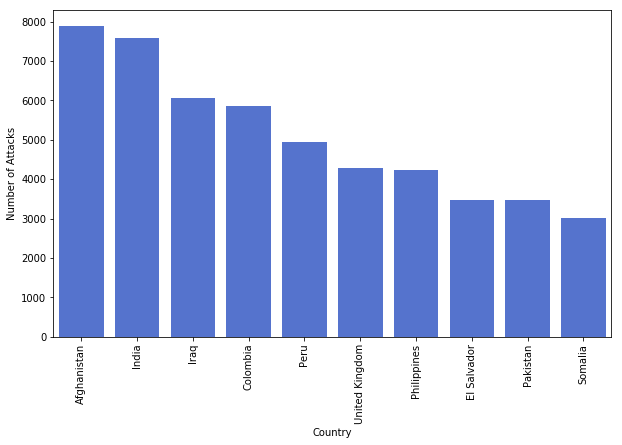

```python
# Top 10 countries which are mostly attacked

#print(df.columns)
#df_attack = df[df['Attack_type']=='Bombing/Explosion']
#print(df_attack)
plt.subplots(figsize=(10,6))
attack_in_country = pd.DataFrame(df.groupby(['Country'])['Attack_type'].count())
attack_in_country.reset_index(level=0,inplace=True)
attack_in_country=attack_in_country.rename(columns = {'Attack_type':'Number of Attacks'})
attack_in_country.sort_values(by=['Number of Attacks'],ascending=False,inplace=True)
#print(attack_in_country)
plt.xticks(rotation=90)
final_attacks=attack_in_country.head(10)
ax = sns.barplot(x="Country", y="Number of Attacks", data=final_attacks,color='royalblue')
plt.show()
```

**14) Top 10 countries which are mostly attacked by Bombing**

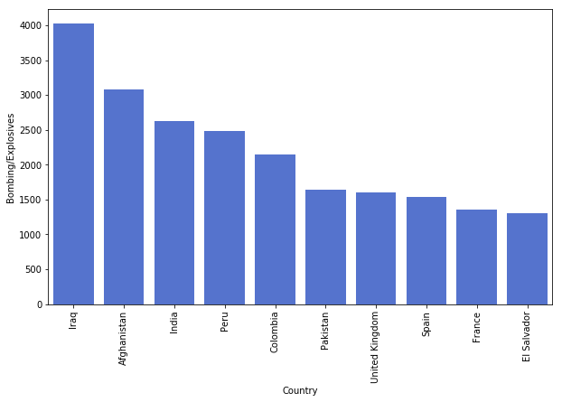

```python
# Top 10 countries which are mostly attacked by Bombing

#print(df.columns)
df_attack = df[df['Attack_type']=='Bombing/Explosion']
#print(df_attack)
plt.subplots(figsize=(10,6))
attack_in_country = pd.DataFrame(df_attack.groupby(['Country'])['Attack_type'].count())
attack_in_country.reset_index(level=0,inplace=True)
attack_in_country=attack_in_country.rename(columns = {'Attack_type':'Bombing/Explosives'})
attack_in_country.sort_values(by=['Bombing/Explosives'],ascending=False,inplace=True)
#print(attack_in_country)
final_attacks=attack_in_country.head(10)
plt.xticks(rotation=90)
ax = sns.barplot(x="Country", y="Bombing/Explosives", data=final_attacks,color='royalblue')
plt.show()
```

**15) Top 10 countries which are mostly attacked by Assasination**

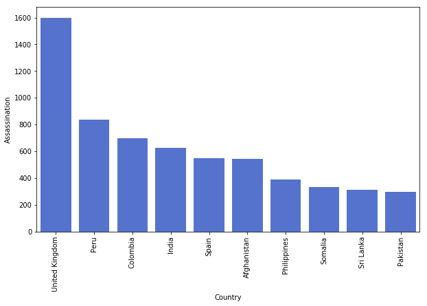

```python
# Top 10 countries which are mostly attacked by Assasination

#print(df.columns)
df_attack = df[df['Attack_type']=='Assassination']
#print(df_attack)
plt.subplots(figsize=(10,6))
plt.xticks(rotation=90)
attack_in_country = pd.DataFrame(df_attack.groupby(['Country'])['Attack_type'].count())
attack_in_country.reset_index(level=0,inplace=True)
attack_in_country=attack_in_country.rename(columns = {'Attack_type':'Assassination'})
attack_in_country.sort_values(by=['Assassination'],ascending=False,inplace=True)
#print(attack_in_country)
final_attacks=attack_in_country.head(10)
ax = sns.barplot(x="Country", y="Assassination", data=final_attacks,color='royalblue')
plt.show()
```

**16) Top 10 countries where the attacks are done on Infrastructure**

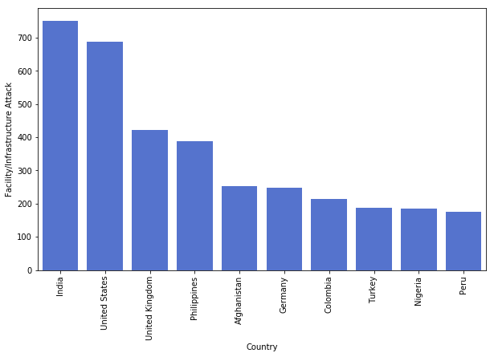

```python
# Top 10 countries where the attacks are done on Infrastructure

#print(df.columns)
df_attack = df[df['Attack_type']=='Facility/Infrastructure Attack']
#print(df_attack)
plt.subplots(figsize=(10,6))
plt.xticks(rotation=90)
attack_in_country = pd.DataFrame(df_attack.groupby(['Country'])['Attack_type'].count())
attack_in_country.reset_index(level=0,inplace=True)
attack_in_country=attack_in_country.rename(columns = {'Attack_type':'Facility/Infrastructure Attack'})
attack_in_country.sort_values(by=['Facility/Infrastructure Attack'],ascending=False,inplace=True)
#print(attack_in_country)
final_attacks=attack_in_country.head(10)
ax = sns.barplot(x="Country", y="Facility/Infrastructure Attack", data=final_attacks,color='royalblue')
plt.show()
```

**17) Top 10 countries where the attacks are done by Armed Assaults**

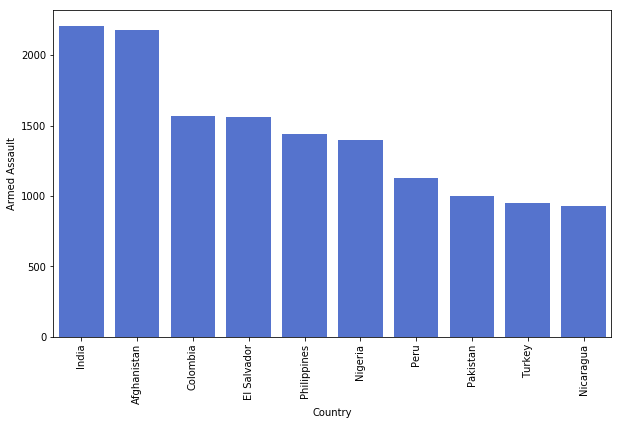

```python
# Top 10 countries where the attacks are done by Armed Assaults

#print(df.columns)
df_attack = df[df['Attack_type']=='Armed Assault']
#print(df_attack)
plt.subplots(figsize=(10,6))
plt.xticks(rotation=90)
attack_in_country = pd.DataFrame(df_attack.groupby(['Country'])['Attack_type'].count())
attack_in_country.reset_index(level=0,inplace=True)
attack_in_country=attack_in_country.rename(columns = {'Attack_type':'Armed Assault'})
attack_in_country.sort_values(by=['Armed Assault'],ascending=False,inplace=True)
#print(attack_in_country)
final_attacks=attack_in_country.head(10)
ax = sns.barplot(x="Country", y="Armed Assault", data=final_attacks,color='royalblue')
plt.show()
```

From the Visualizations 14,15,16 and 17, we can see that terrorism in the form of bombing and armed assaults has been used to affect the civilians and thereby impact the government in most of the developing countries like India, Afghanistan etc.

Whereas, terrorism has been used in the form of assasination of popular persons or leaders in developed countries like United Kingdom.

**18) Groups and their total number of attacks with their type**

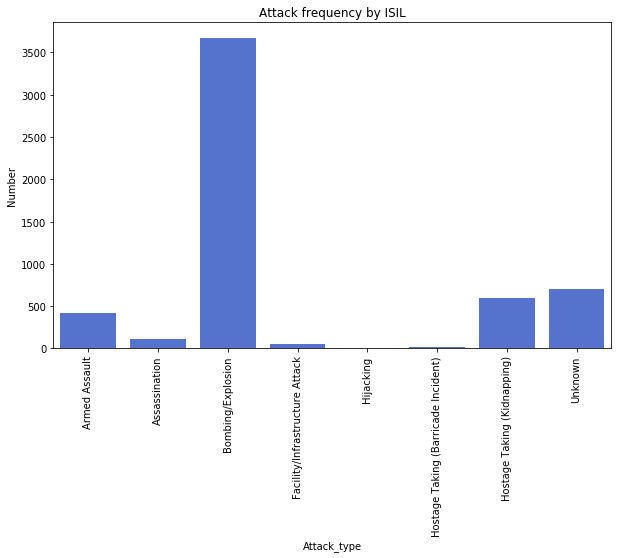

```python
# Groups and their total number of attacks with their type

#print(df.columns)
df_group = df[df['gname']=='Islamic State of Iraq and the Levant (ISIL)']
#print(df_attack)
#Islamic State of Iraq and the Levant (ISIL)
plt.subplots(figsize=(10,6))
plt.xticks(rotation=90)
attacks_by_ISIL = pd.DataFrame(df_group.groupby(['Attack_type'])['Attack_type'].count())
attacks_by_ISIL = attacks_by_ISIL.rename(columns = {'Attack_type':'Number'})
attacks_by_ISIL.reset_index(level=0,inplace=True)

#print(attacks_by_ISIL.head(8))
#attack_in_country.sort_values(by=['Assassination'],ascending=False,inplace=True)
#print(attack_in_country)
#final_attacks=attack_in_country.head(10)
ax = sns.barplot(x="Attack_type", y="Number", data=attacks_by_ISIL,color='royalblue')
ax.set_title("Attack frequency by ISIL")
plt.show()
```

**19) Identifying the frequent targets**

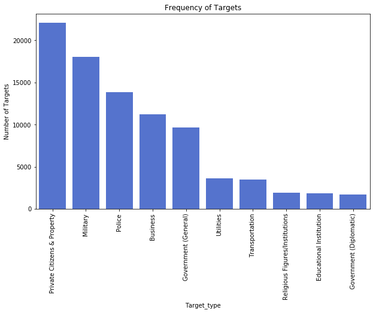

```python
#Identifying the frequent targets
plt.subplots(figsize=(10,6))
plt.xticks(rotation=90)
df = df[~df['gname'].isin(['Unknown'])]
df = df[~df['Target_type'].isin(['Unknown','Other'])]
df14 = pd.DataFrame(df.groupby(['Target_type'])['Target_type'].count())
#df13.reset_index(level=0,inplace=True)

df14 = df14.rename(columns={'Target_type':'Number of Targets'})
#df13 = df13.rename(columns={'count':'Number of attacks'})
df14 = df14.sort_values(by=['Number of Targets'], ascending = False)
#df13 = df13.astype({"Number of people killed": int})
df14.reset_index(level=0,inplace=True)
df15=(df14.head(10))
ax = sns.barplot(x="Target_type", y="Number of Targets", data=df15,color='royalblue')
ax.set_title("Frequency of Targets")
plt.show()
```

**20) Identifying the frequent targets by the terrorist group**

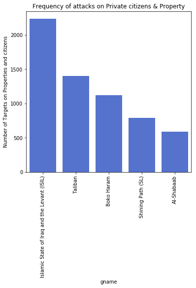

```python
#Identifying the frequent targets by the terrorist group
plt.subplots(figsize=(6,6))
plt.xticks(rotation=90)
df17=df[df['Target_type']=='Private Citizens & Property']
df17 = df17[~df17['gname'].isin(['Unknown'])]
#df17 = df17[~df17['Target_type'].isin(['Unknown','Other'])]
df18 = pd.DataFrame(df17.groupby(['gname'])['Target_type'].count())
#df13.reset_index(level=0,inplace=True)

df18 = df18.rename(columns={'Target_type':'Number of Targets on Properties and citizens'})
#df13 = df13.rename(columns={'count':'Number of attacks'})
df18 = df18.sort_values(by=['Number of Targets on Properties and citizens'], ascending = False)
#df13 = df13.astype({"Number of people killed": int})
df18.reset_index(level=0,inplace=True)
df19=(df18.head(5))
ax = sns.barplot(x="gname", y="Number of Targets on Properties and citizens", data=df19,color='royalblue')
ax.set_title("Frequency of attacks on Private citizens & Property")
plt.show()
```

Visualization 19 shows the frequent targets which are being attacked by the terrorist groups out of which "Private Citizens and Property" is attacked the most over 20000 times across various countries.

**21) Attacks on Military**

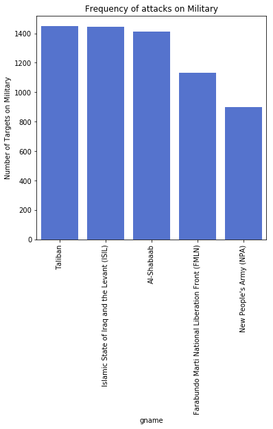

```python
#Attacks on Military
plt.subplots(figsize=(6,6))
plt.xticks(rotation=90)
df17=df[df['Target_type']=='Military']
df17 = df17[~df17['gname'].isin(['Unknown'])]
#df17 = df17[~df17['Target_type'].isin(['Unknown','Other'])]
df18 = pd.DataFrame(df17.groupby(['gname'])['Target_type'].count())
#df13.reset_index(level=0,inplace=True)

df18 = df18.rename(columns={'Target_type':'Number of Targets on Military'})
#df13 = df13.rename(columns={'count':'Number of attacks'})
df18 = df18.sort_values(by=['Number of Targets on Military'], ascending = False)
#df13 = df13.astype({"Number of people killed": int})
df18.reset_index(level=0,inplace=True)
df19=(df18.head(5))
ax = sns.barplot(x="gname", y="Number of Targets on Military", data=df19,color='royalblue')
ax.set_title("Frequency of attacks on Military")
plt.show()
```

The War in Afghanistan is the longest war in U.S. history. This war was code named Operation Enduring Freedom – Afghanistan (2001–14). The war's public aims were to save Afghanistan by removing the Taliban from power following the September 11 attacks in 2001 on the U.S.

From the above Visualization we could see that the most number of attacks on Military were done by the Taliban. This clearly reflects the situation in Afghanistan were many US Army troops were constantly being attacked by the Taliban which were a local terrorist group in Afghanistan.

Source: https://en.wikipedia.org/wiki/War_in_Afghanistan_(2001%E2%80%93present)

**22) Attacks by Taliban on various targets**

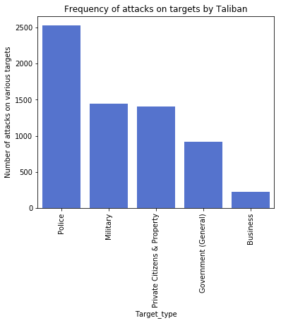

|  | Target_type | Number of attacks on various targets |
| --- | --- | --- |
| 0 | Police | 2530 |
| 1 | Military | 1448 |
| 2 | Private Citizens & Property | 1404 |
| 3 | Government (General) | 916 |
| 4 | Business | 226 |

```python
#Attacks by Taliban on various targets
plt.subplots(figsize=(6,5))
plt.xticks(rotation=90)
df17=df[df['gname']=='Taliban']
#df17 = df17[~df17['gname'].isin(['Unknown'])]
#df17 = df17[~df17['Target_type'].isin(['Unknown','Other'])]
df18 = pd.DataFrame(df17.groupby(['Target_type'])['Target_type'].count())
#df13.reset_index(level=0,inplace=True)

df18 = df18.rename(columns={'Target_type':'Number of attacks on various targets'})
#df13 = df13.rename(columns={'count':'Number of attacks'})
df18 = df18.sort_values(by=['Number of attacks on various targets'], ascending = False)
#df13 = df13.astype({"Number of people killed": int})
df18.reset_index(level=0,inplace=True)
df19=(df18.head(5))
ax = sns.barplot(x="Target_type", y="Number of attacks on various targets", data=df19,color='royalblue')
ax.set_title("Frequency of attacks on targets by Taliban")
plt.show()
display(df19)
```

**23) Weapons mostly used by Taliban**

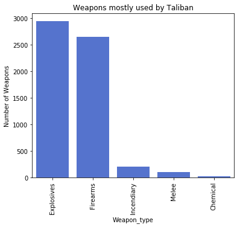

|  | Weapon_type | Number of Weapons |
| --- | --- | --- |
| 0 | Explosives | 2939 |
| 1 | Firearms | 2646 |
| 2 | Incendiary | 206 |
| 3 | Melee | 102 |
| 4 | Chemical | 23 |

```python
#Weapons mostly used by Taliban
plt.subplots(figsize=(6,5))
plt.xticks(rotation=90)
df17=df[df['gname']=='Taliban']
df17 = df17[~df17['Weapon_type'].isin(['Unknown'])]
#df17 = df17[~df17['Target_type'].isin(['Unknown','Other'])]
df18 = pd.DataFrame(df17.groupby(['Weapon_type'])['Weapon_type'].count())
#df13.reset_index(level=0,inplace=True)

df18 = df18.rename(columns={'Weapon_type':'Number of Weapons'})
#df13 = df13.rename(columns={'count':'Number of attacks'})
df18 = df18.sort_values(by=['Number of Weapons'], ascending = False)
#df13 = df13.astype({"Number of people killed": int})
df18.reset_index(level=0,inplace=True)
df19=(df18.head(5))
ax = sns.barplot(x="Weapon_type", y="Number of Weapons", data=df19,color='royalblue')
ax.set_title("Weapons mostly used by Taliban")
plt.show()
display(df19)
```

**24) Terrorist groups and count of no of attacks on various countries based on years**

```
Attacks by Islamic State of Iraq and the Levant (ISIL)
```

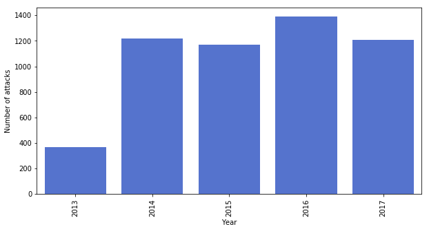

```
Attacks by Taliban
```

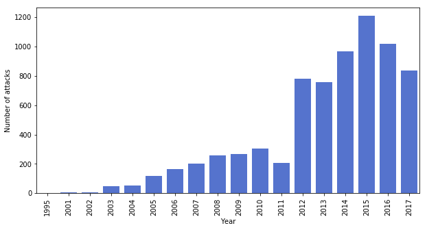

```
Attacks by Boko Haram
```

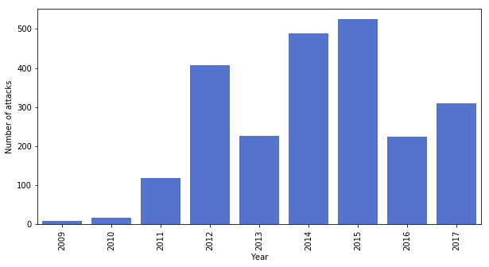

```
Shining Path (SL)
```

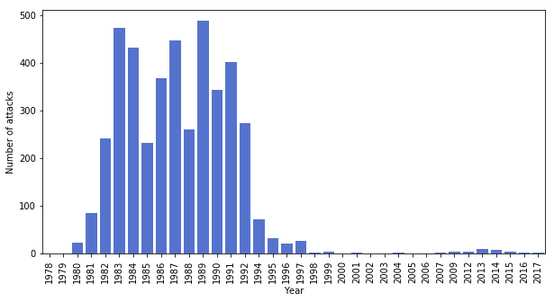

```
Liberation Tigers of Tamil Eelam (LTTE)
```

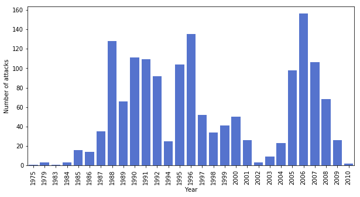

```python
import seaborn as sns
from matplotlib import pyplot as plt
def attacks_country(gname):
    df_ISIL = df[df["gname"]==gname]
    #display(df_ISIL)
    #df['Weapon_type'].fillna(0)
    attacks_on_country_year = df_ISIL.groupby(['Year'])['Country'].count()
    #weapons = df.groupby(['Weapon_type'])['Year'].count()
    plt.subplots(figsize=(10,5))
    plt.xticks(rotation=90)
    pt_ISIL_countries = sns.barplot(attacks_on_country_year.index,attacks_on_country_year,color='royalblue')
    pt_ISIL_countries.set_xlabel("Year")
    pt_ISIL_countries.set_ylabel("Number of attacks")

    pt_ISIL_countries.set_xticklabels(attacks_on_country_year.index,rotation=90)
    plt.show()
print("Attacks by Islamic State of Iraq and the Levant (ISIL)")
attacks_country("Islamic State of Iraq and the Levant (ISIL)")
print("Attacks by Taliban")
attacks_country("Taliban")
print("Attacks by Boko Haram")
attacks_country("Boko Haram")
print("Shining Path (SL)")
attacks_country("Shining Path (SL)")
print("Liberation Tigers of Tamil Eelam (LTTE)")
attacks_country("Liberation Tigers of Tamil Eelam (LTTE)")
```

**25) Identifying how lethal are the attacks over the years**

|  | Year | Number of people killed | Number of attacks | Ratio |
| --- | --- | --- | --- | --- |
| 0 | 1970 | 120 | 523 | 0.229446 |
| 1 | 1971 | 139 | 367 | 0.378747 |
| 2 | 1972 | 446 | 479 | 0.931106 |
| 3 | 1973 | 319 | 351 | 0.908832 |
| 4 | 1974 | 514 | 460 | 1.117391 |
| 5 | 1975 | 598 | 597 | 1.001675 |
| 6 | 1976 | 592 | 598 | 0.989967 |
| 7 | 1977 | 263 | 768 | 0.342448 |
| 8 | 1978 | 1245 | 970 | 1.283505 |
| 9 | 1979 | 1414 | 1713 | 0.825452 |

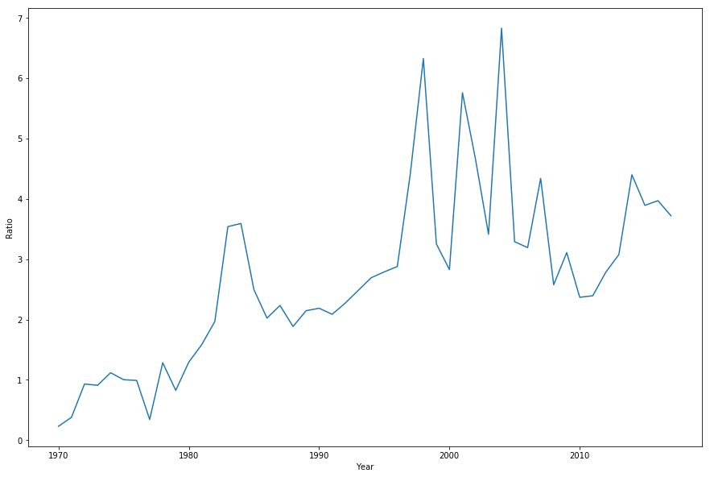

```python
plt.subplots(figsize=(15,10))
df = df[~df['gname'].isin(['Unknown'])]
df_deadliest = pd.DataFrame(df.groupby(['Year'])['Number_of_killed'].agg(['sum','count']))

df_deadliest.reset_index(level=0,inplace=True)

df_deadliest = df_deadliest.rename(columns={'sum':'Number of people killed'})
df_deadliest = df_deadliest.rename(columns={'count':'Number of attacks'})

#df13['proportion_killed'] = (df13['Number of people killed']/np.sum(df13['Number of people killed']))
#df13['proportion_attacks'] = (df13['Number of attacks']/np.sum(df13['Number of attacks']))
#df13 = df13.sort_values(by=['Number of people killed','Number of attacks'], ascending = False)
df_deadliest = df_deadliest.astype({"Number of people killed": int})
df_deadliest['Ratio'] = (df_deadliest['Number of people killed']/(df_deadliest['Number of attacks']))
df_deadliest.reset_index(level=0,inplace=True,drop=True)
display(df_deadliest.head(10))
t = sns.lineplot(x='Year',y='Ratio',data=df_deadliest)
t.set_xlabel("Year")
plt.show()
```

From the above Visualization 25, we could see the lethality of the attacks over the years based on the ratio of the number of people killed to the number of attacks. The lethality of the attacks being directly proportional to this ratio.

**HEATMAPS:**

```python
table1 = df.groupby(['Attack_type','Weapon_type'])['Number_of_killed'].median().unstack()
table2 = df.groupby(['Attack_type','Weapon_type'])['Number_of_killed'].count().unstack()
```

**26) Heatmap of Attack type, Weapon type based on the Median number of people killed in the attack**

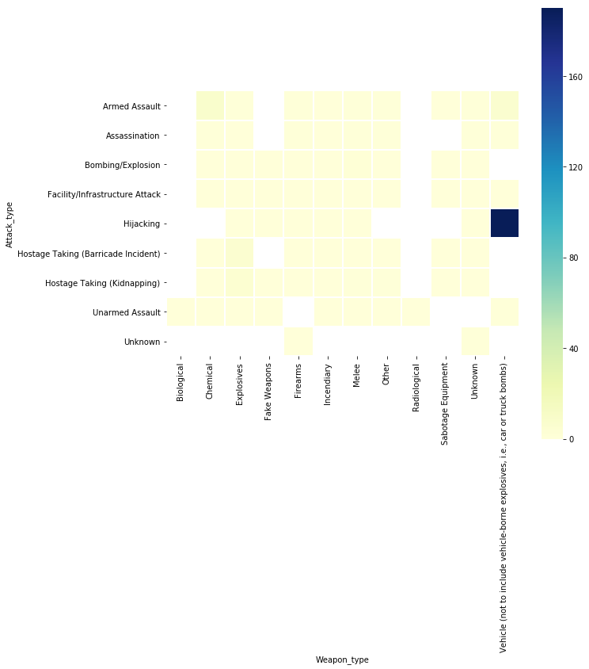

```python
plt.figure(figsize=(10,10))
sns.heatmap(table1, cmap='YlGnBu', square=True, linewidths=1);
```

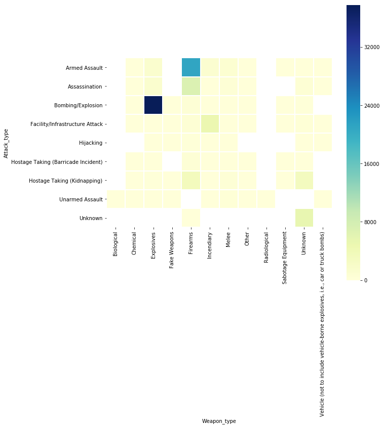

```python
plt.figure(figsize=(10,10))
sns.heatmap(table2, cmap='YlGnBu', square=True, linewidths=1);
```

**28) Stacked bar plot of various types of attacks over the past decade.**

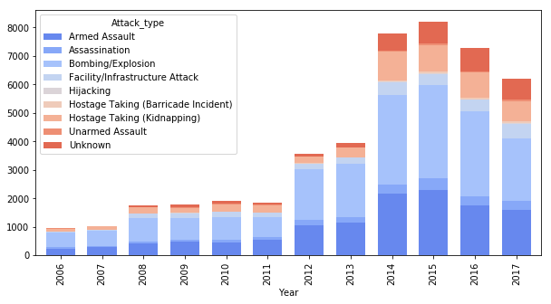

```python
import matplotlib.pyplot as plt
import matplotlib
import seaborn as sns
from matplotlib.colors import LinearSegmentedColormap
#matplotlib.style.use('ggplot')

colors = sns.color_palette("coolwarm")
cmap1 = LinearSegmentedColormap.from_list("my_colormap", colors)



df10=df[df['Year'].isin({"2006","2007","2008","2009","2010","2011","2012","2013","2014","2015","2016","2017"})]
attack_in_year = pd.DataFrame(df10.groupby(['Year','Attack_type'])['Attack_type'].count().unstack())
#print(attack_in_year)
#print(attack_in_year)
attack_in_year.plot(kind='bar',stacked=True,figsize=(10,5),width=0.7,colormap=cmap1)
```

**29) Stacked bar plot of various Target types over the past decade.**

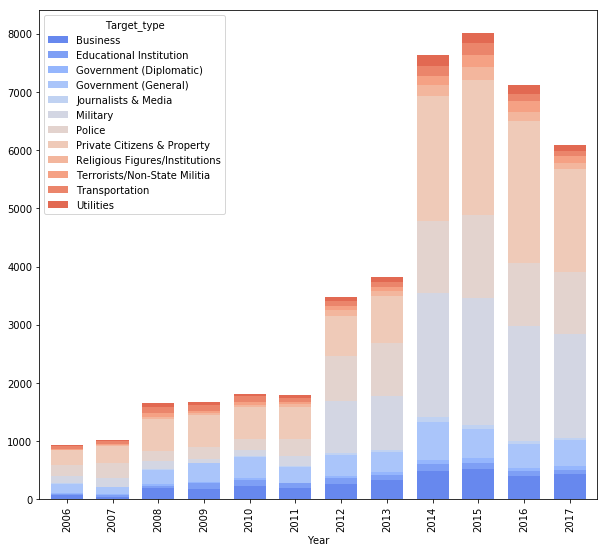

```python
import matplotlib.pyplot as plt
import matplotlib
import seaborn as sns
#df11=df[df['Year'].isin({"2006","2007","2008","2009","2010","2011","2012","2013","2014","2015","2016","2017"})]
Target_in_year = pd.DataFrame(df.groupby(['Target_type'])['Target_type'].count())
Target_in_year = Target_in_year.rename(columns={'Target_type':'Count of attacks'})
Target_in_year.reset_index(level=None,inplace=True)
Target_in_year = Target_in_year[Target_in_year['Count of attacks']>=1000]
Target_list=list(Target_in_year['Target_type'])
#print(Target_list)
df_target=df[df['Year'].isin({"2006","2007","2008","2009","2010","2011","2012","2013","2014","2015","2016","2017"})]
df_target=df_target[df_target['Target_type'].isin(Target_list)]
#display(df_target)
#display(df_target)
df13=pd.DataFrame(df_target.groupby(['Year','Target_type'])['Target_type'].count().unstack())
df13=df13.rename(columns={'Target_type':'Count of attacks'})
#print(df13)
df13.plot(kind='bar',stacked=True,figsize=(10,9),width=0.7,colormap=cmap1)

#display(df13)
```

**30) Stacked bar plot of various Property types attacked over the past decade.**

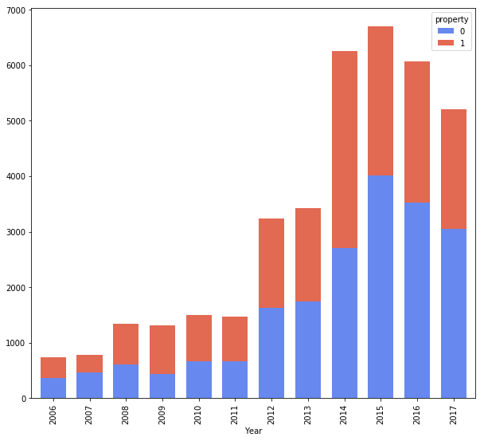

```python
# Destruction done on property over the years
import matplotlib.pyplot as plt
import matplotlib
import seaborn as sns

#plt.subplots(figsize=(15,6))
df1=df[df['property']!=-9]
df1=df1[df1['Year'].isin({"2006","2007","2008","2009","2010","2011","2012","2013","2014","2015","2016","2017"})]
attack_on_property = pd.DataFrame(df1.groupby(['Year','property'])['property'].count().unstack())
#attack_on_property.reset_index(level=0,inplace=True)
attack_on_property=attack_on_property.rename(columns = {'property':'Count of attacks'})
#attack_on_property.sort_values(by=['Count of attacks'],ascending=False,inplace=True)
#display(attack_on_property)
attack_on_property.plot(kind='bar',stacked=True,figsize=(10,9),width=0.7,colormap=cmap1)


#sub_df2=attack_on_property.unstack().T
#sub_df2.columns=sub_df2.columns.droplevel()
#sub_df2=sub_df2.div(sub_df2.sum())
#sub_df2.T.plot(kind='bar',stacked=True,figsize=(8,8))
```

**31) Destruction done on property over the past decade.**

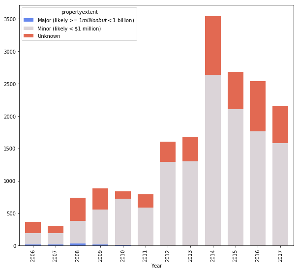

```python
# Destruction done on property based on the last 10 years [Extent]
import matplotlib.pyplot as plt
import matplotlib
import seaborn as sns

#plt.subplots(figsize=(15,6))
df1=df[df['property']==1]
df1=df1[df1['Year'].isin({"2006","2007","2008","2009","2010","2011","2012","2013","2014","2015","2016","2017"})]
attack_on_property = pd.DataFrame(df1.groupby(['Year','propertyextent'])['propertyextent'].count().unstack())
#attack_on_property.reset_index(level=0,inplace=True)
attack_on_property=attack_on_property.rename(columns = {'propertyextent':'Count of attacks'})
#attack_on_property.sort_values(by=['Count of attacks'],ascending=False,inplace=True)
#display(attack_on_property)
attack_on_property.plot(kind='bar',stacked=True,figsize=(10,9),width=0.7,colormap=cmap1)


#sub_df2=attack_on_property.unstack().T
#sub_df2.columns=sub_df2.columns.droplevel()
#sub_df2=sub_df2.div(sub_df2.sum())
#sub_df2.T.plot(kind='bar',stacked=True,figsize=(8,8))
```

**32) Failed attacks over the past decade. (Number of killed=0 is the criteria)**

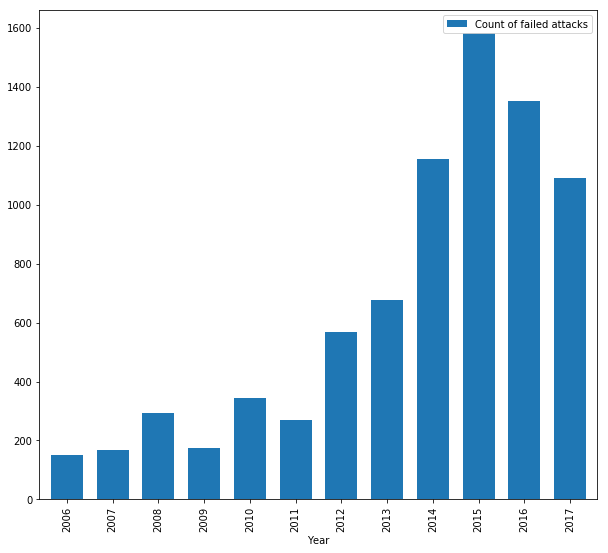

```python
# Failed attacks
import matplotlib.pyplot as plt
import matplotlib
import seaborn as sns

#plt.subplots(figsize=(15,6))
df1=df[df['property']==0]
df1=df1[df1['Number_of_killed']==0]

df1=df1[df1['Year'].isin({"2006","2007","2008","2009","2010","2011","2012","2013","2014","2015","2016","2017"})]

attack_on_property = pd.DataFrame(df1.groupby(['Year'])['property'].count())
#attack_on_property.reset_index(level=0,inplace=True)
attack_on_property=attack_on_property.rename(columns = {'property':'Count of failed attacks'})
#attack_on_property.sort_values(by=['Count of attacks'],ascending=False,inplace=True)
#display(attack_on_property)
attack_on_property.plot(kind='bar',figsize=(10,9),width=0.7)


#sub_df2=attack_on_property.unstack().T
#sub_df2.columns=sub_df2.columns.droplevel()
#sub_df2=sub_df2.div(sub_df2.sum())
#sub_df2.T.plot(kind='bar',stacked=True,figsize=(8,8))
```

**33) The total number of years each of the terrorist groups are active.**

```python
#plt.subplots(figsize=(15,10))
df = df[~df['gname'].isin(['Unknown'])]
df_deadliest = pd.DataFrame(df.groupby(['gname'])['Year'].agg(['min','max']))
#display(df_deadliest)
df_deadliest['Years active'] = df_deadliest['max']-df_deadliest['min']+1
#display(df_deadliest)
df_deadliest.sort_values(by=['Years active'],ascending=False,inplace=True)
display(df_deadliest)
```

| gname | min | max | Years active |
| --- | --- | --- | --- |
| Neo-Nazi extremists | 1970 | 2017 | 48 |
| White extremists | 1970 | 2017 | 48 |
| Right-wing extremists | 1970 | 2017 | 48 |
| New People's Army (NPA) | 1970 | 2017 | 48 |
| Ulster Volunteer Force (UVF) | 1970 | 2017 | 48 |
| Popular Front for the Liberation of Palestine (PFLP) | 1970 | 2017 | 48 |
| Ku Klux Klan | 1970 | 2017 | 48 |
| Left-wing extremists | 1971 | 2017 | 47 |
| National Liberation Army of Colombia (ELN) | 1972 | 2017 | 46 |
| Ulster Freedom Fighters (UFF) | 1972 | 2017 | 46 |
| Popular Liberation Army (EPL) | 1973 | 2017 | 45 |
| Protestant extremists | 1970 | 2013 | 44 |
| Anti-Government extremists | 1974 | 2017 | 44 |
| Jewish Defense League (JDL) | 1970 | 2013 | 44 |
| Popular Front for the Liberation of Palestine, Gen Cmd (PFLP-GC) | 1970 | 2013 | 44 |
| Moro National Liberation Front (MNLF) | 1975 | 2017 | 43 |
| Irish National Liberation Army (INLA) | 1975 | 2016 | 42 |
| Basque Fatherland and Freedom (ETA) | 1970 | 2011 | 42 |
| Communists | 1976 | 2017 | 42 |
| Irish Republican Army (IRA) | 1970 | 2011 | 42 |
| Jewish Extremists | 1974 | 2015 | 42 |
| Revolutionary Armed Forces of Colombia (FARC) | 1975 | 2016 | 42 |
| Irish Republican Extremists | 1970 | 2010 | 41 |
| Democratic Front for the Liberation of Palestine (DFLP) | 1974 | 2014 | 41 |
| Breton Liberation Front (FLB) | 1974 | 2014 | 41 |
| Tigray Peoples Liberation Front (TPLF) | 1976 | 2016 | 41 |
| National Union for the Total Independence of Angola (UNITA) | 1978 | 2017 | 40 |
| Corsican Nationalists | 1978 | 2017 | 40 |
| Shining Path (SL) | 1978 | 2017 | 40 |
| Al-Fatah | 1971 | 2009 | 39 |
| ... | ... | ... | ... |
| Association of Demobilized Armed Forces | 1995 | 1995 | 1 |
| Lashkar-e-Islam (India) | 2015 | 2015 | 1 |
| Association for the Enhancement of the Justice of the Great Japan | 1992 | 1992 | 1 |
| Association Totalement Anti-Guerre (ATAG) | 2001 | 2001 | 1 |
| Lashkari-e-Adam (Army of Adam) | 1991 | 1991 | 1 |
| Last Alternative Guerrilla Front | 1996 | 1996 | 1 |
| Last Generation | 2000 | 2000 | 1 |
| Aryan Brotherhood | 1978 | 1978 | 1 |
| Latin American Anti-Fascist Command | 1987 | 1987 | 1 |
| Latvian Republic Volunteer Troops | 1992 | 1992 | 1 |
| Lavalas Supporters | 1995 | 1995 | 1 |
| La Paz peasants federation | 1984 | 1984 | 1 |
| LW | 2008 | 2008 | 1 |
| Kyongbuk University Dental College Students | 1991 | 1991 | 1 |
| Autonomous Anarchist Groups | 1979 | 1979 | 1 |
| Kurdish Independence Group (name unk) | 1988 | 1988 | 1 |
| Kurdish Islamic Unity Party | 1995 | 1995 | 1 |
| Kurdish Marxist Separatists | 1979 | 1979 | 1 |
| Autonomous Decorators | 2000 | 2000 | 1 |
| Kurdish Oppositionists | 1982 | 1982 | 1 |
| Kurdish Peshmerga Guerrillas | 1991 | 1991 | 1 |
| Authenticity and Development Front | 2016 | 2016 | 1 |
| Association of Students and Pupils in Mali (AEEM) | 1994 | 1994 | 1 |
| Kurdish demonstrators | 1992 | 1992 | 1 |
| Attack Teams for the Dissolution of the Nation (Greece) | 2009 | 2009 | 1 |
| Attaches | 1995 | 1995 | 1 |
| Athens and Thessaloniki Arsonist Nuclei | 2007 | 2007 | 1 |
| Kurdistan National Union | 1987 | 1987 | 1 |
| Asylum Seekers | 1992 | 1992 | 1 |
| leftist guerrillas-Bolivarian militia | 1995 | 1995 | 1 |

3446 rows × 3 columns

**34) Box and strip plots of the total number of years each of the terrorist groups are active.**

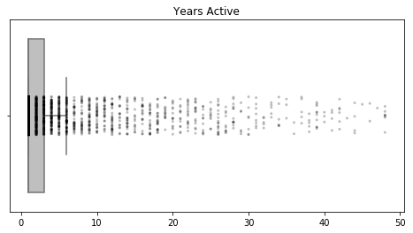

```python
plt.figure(figsize=(8,4))
sns.boxplot((df_deadliest['Years active']),color='0.75',fliersize=0)
sns.stripplot((df_deadliest['Years active']),color='k',size=3,alpha=0.25)
#plt.hist(df_deadliest['Years active'],bins=np.logspace(np.log10(0.1),np.log10(1.0),20))
#pl.figure()
plt.xlabel('')
plt.title('Years Active')
```

The above visualization shows the distribution of the active number of years of all the terrorist groups from the year of its origin.

**The following function attack_stats gives the specific details of the country which is sent as an argument to it.**

```python
# Number of attacks done by a particular terrorist group over a range of years

#df = df[~df['gname'].isin(['Unknown'])]
#df_deadliest = pd.DataFrame(df.groupby(['Year'])['Number_of_killed'].agg(['sum','count']))

def attack_stats(df9,country):
    data = df9[(df9['Country']==country)]
    data = data[~data['gname'].isin(['Unknown'])]
    terr_groups1 = pd.DataFrame(data.groupby(['gname'])['Number_of_killed'].agg(['sum','count']))
    terr_groups = pd.DataFrame(data.groupby(['gname'])['Number_of_killed'].count())
    #display(terr_groups)
    terr_groups = terr_groups.rename(columns={'Number_of_killed':'Number of attacks'})
    terr_groups.sort_values(by=['Number of attacks'],ascending=False,inplace=True)
    terr_groups1 = terr_groups1.rename(columns={'sum':'Number of people killed'})
    terr_groups1 = terr_groups1.rename(columns={'count':'Number of attacks'})
    terr_groups1 = terr_groups1.astype({"Number of people killed": int})
    plt.plot(terr_groups1['Number of people killed'],terr_groups1['Number of attacks'],'k.')
    plt.xlabel('Number of people killed')
    plt.ylabel('Number of attacks')
    plt.title('Correlation = %.4f' % terr_groups1['Number of people killed'].corr(terr_groups1['Number of attacks']));
    #terr_groups['Ratio'] = (terr_groups['Number of people killed']/(terr_groups['Number of attacks']))
    #terr_groups = terr_groups.sort_values(by=['Ratio'], ascending = False)
    #display(terr_groups1.head(10))
    #plot2 = sns.barplot(attacks_month.index ,attacks_month)
    #plot2.set_xlabel('Months')
    #plot2.set_ylabel('Number of Attacks')
    #plot2.set_title(gname + " in "+str(year))
    #plt.show()
    df1 = df9[(df9['Country']==country)]
    df1=df1[df1['property']==1]
    df1=df1[df1['Year'].isin({"2006","2007","2008","2009","2010","2011","2012","2013","2014","2015","2016","2017"})]
    attack_on_property_country = pd.DataFrame(df1.groupby(['Year','propertyextent'])['propertyextent'].count().unstack())
#attack_on_property.reset_index(level=0,inplace=True)
    attack_on_property_country=attack_on_property_country.rename(columns = {'propertyextent':'Count of attacks'})
#attack_on_property.sort_values(by=['Count of attacks'],ascending=False,inplace=True)
#display(attack_on_property)
    attack_on_property_country.plot(kind='bar',stacked=True,figsize=(15,15),width=0.7,colormap=cmap1)
    df1 = df9[(df9['Country']==country)]
    df1=df1[df1['Year'].isin({"2006","2007","2008","2009","2010","2011","2012","2013","2014","2015","2016","2017"})]
    people_killed = pd.DataFrame(df1.groupby(['Year'])['Number_of_killed'].count())
    people_killed.sort_values(by=['Number_of_killed'],ascending=True,inplace=True)
    people_killed.plot(kind='bar',figsize=(10,9),width=0.7,colormap=cmap1)
    df1 = df9[(df9['Country']==country)]
    df1=df1[df1['Year'].isin({"2006","2007","2008","2009","2010","2011","2012","2013","2014","2015","2016","2017"})]
    df1_target=df1[df1['Target_type'].isin(Target_list)]
#display(df_target)
#display(df_target)
    df_Target_country=pd.DataFrame(df1_target.groupby(['Year','Target_type'])['Target_type'].count().unstack())
    df_Target_country=df_Target_country.rename(columns={'Target_type':'Count of attacks'})
#print(df13)
    df_Target_country.plot(kind='bar',stacked=True,figsize=(15,15),width=0.7,colormap=cmap1)
    ### Attack type
    df1 = df9[(df9['Country']==country)]
    df1=df1[df1['Year'].isin({"2006","2007","2008","2009","2010","2011","2012","2013","2014","2015","2016","2017"})]
    df_Attack_type_country=pd.DataFrame(df1.groupby(['Year','Attack_type'])['Attack_type'].count().unstack())
    df_Attack_type_country=df_Attack_type_country.rename(columns={'Attack_type':'Count of attacks'})
    df_Attack_type_country.plot(kind='bar',stacked=True,figsize=(15,15),width=0.7,colormap=cmap1)

    df1 = df9[(df9['Country']==country)]
    df1=df1[df1['Year'].isin({"2006","2007","2008","2009","2010","2011","2012","2013","2014","2015","2016","2017"})]
    df_weapon_type_country=pd.DataFrame(df1.groupby(['Year','Weapon_type'])['Weapon_type'].count().unstack())
    df_weapon_type_country=df_weapon_type_country.rename(columns={'Weapon_type':'Count used'})
    df_weapon_type_country.plot(kind='bar',stacked=True,figsize=(29,20),width=0.7,colormap=cmap1)

    ### Pie chart (Overall)
    #df_pie=pd.DataFrame(df1.groupby(['Weapon_type'])['Weapon_type'].count())
    #df_pie=df_pie.rename(columns={'Weapon_type':'Number of attacks'})
    #df_pie.reset_index(level=None,inplace=True)
    #display(df_pie)
    #plt.pie(df_pie['Number of attacks'], labels=df_pie['Weapon_type'], colors=None, shadow=False, startangle=90)
    #plt.axis('equal')
    #plt.pie(df_weapon_type_country['Count used'],)
```

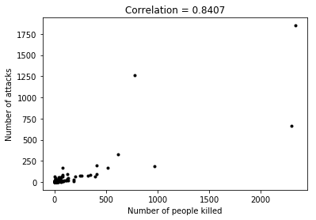

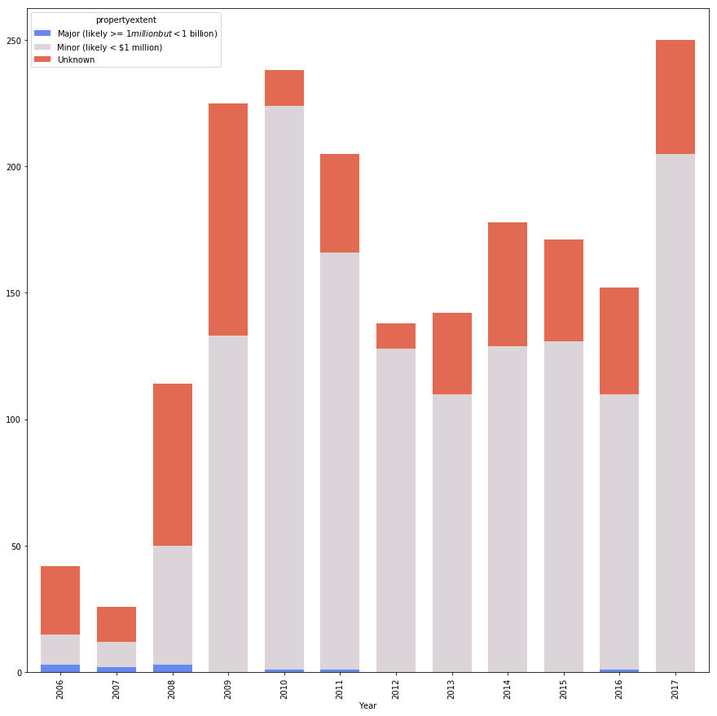

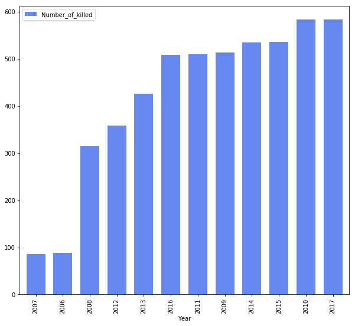

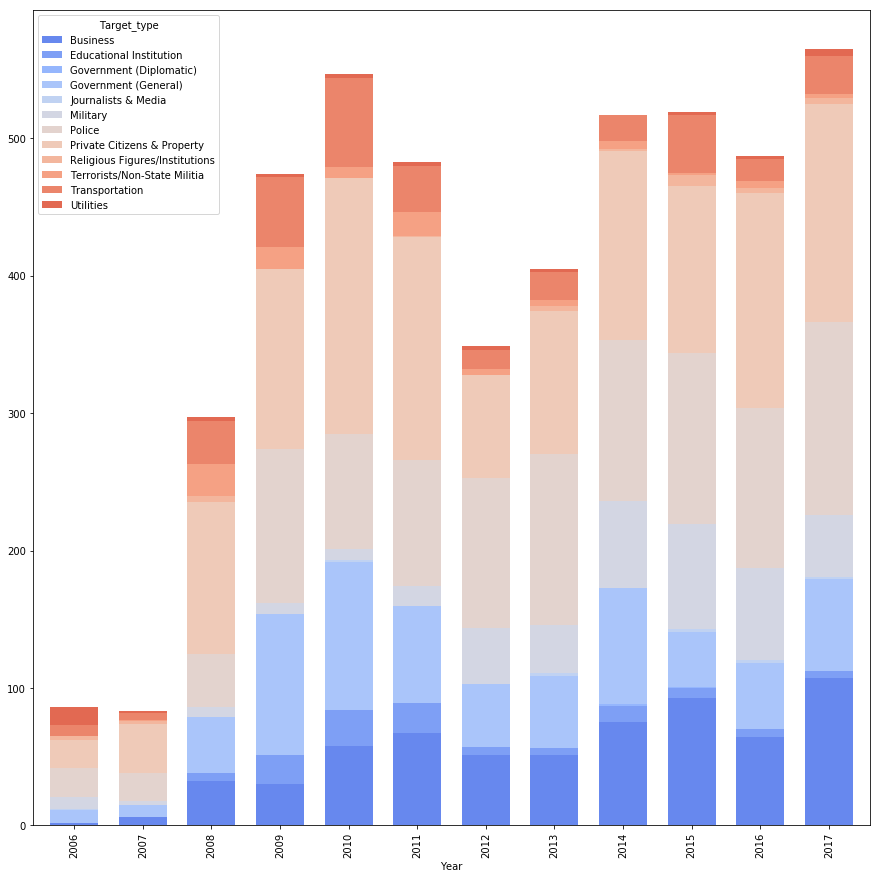

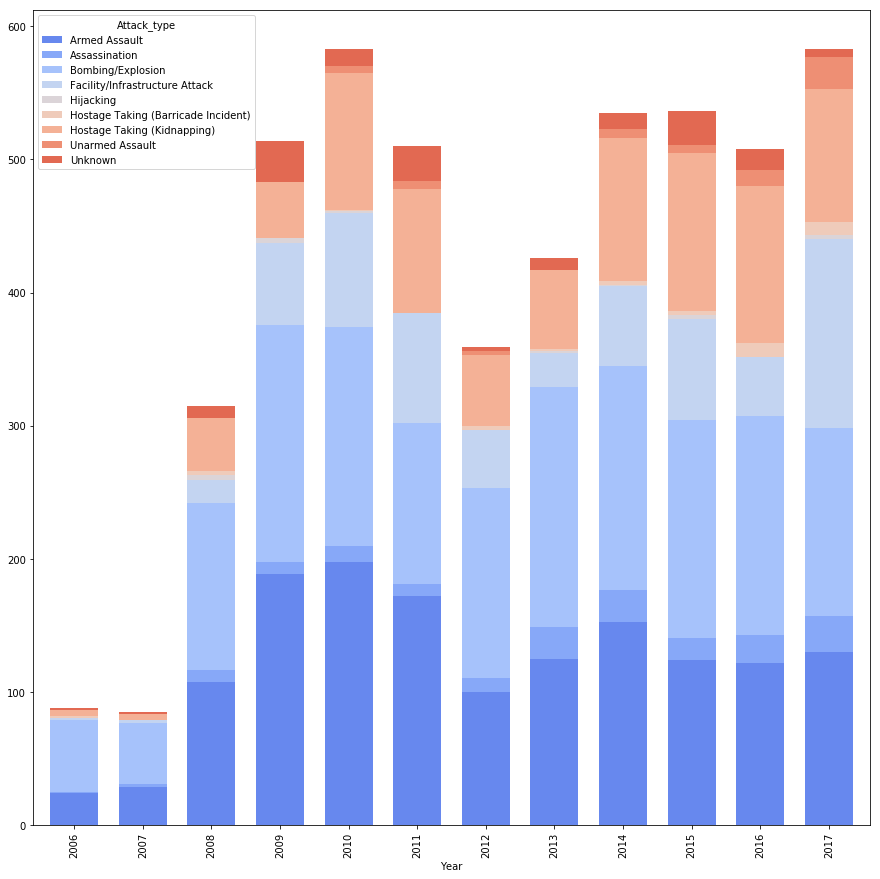

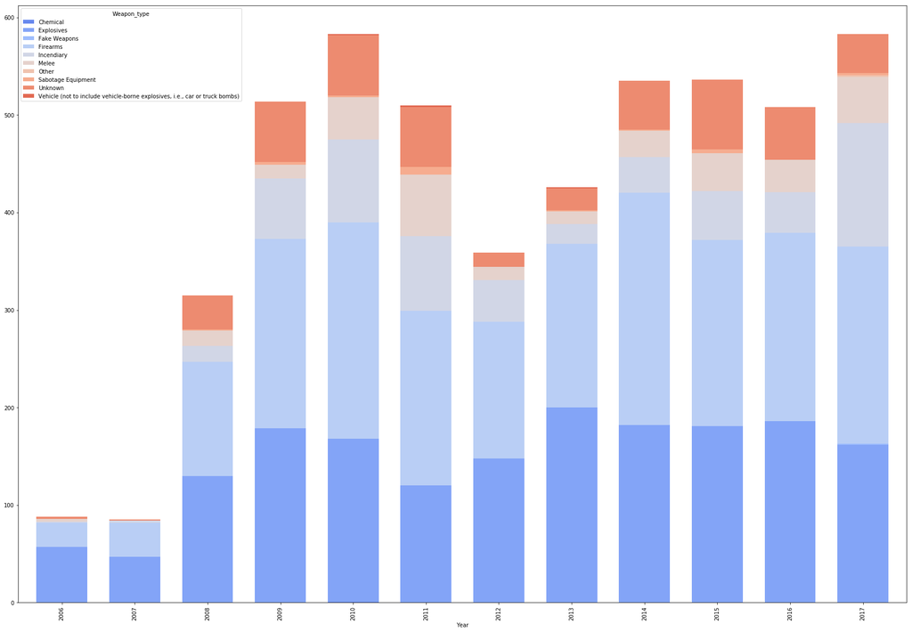

```python
attack_stats(df,"India")
```

**The function attack_stats gives us the statistics regarding:**

1) The visualization between the number of people killed and the number of attacks

2) Extent of property damage over the past decade

4) Type of target over the past decade

5) Type of attack over the past decade

6) Type of weapon over the past decade

All these stats can be specifically obtained for any country present in our dataset by passing the country name to the attack_stats function.